# Equity: ECE Occupied Seats Per Child

Brook Frye

2026-07-23

#### Relationship between 3-4 year olds and occupied seats by PUMA

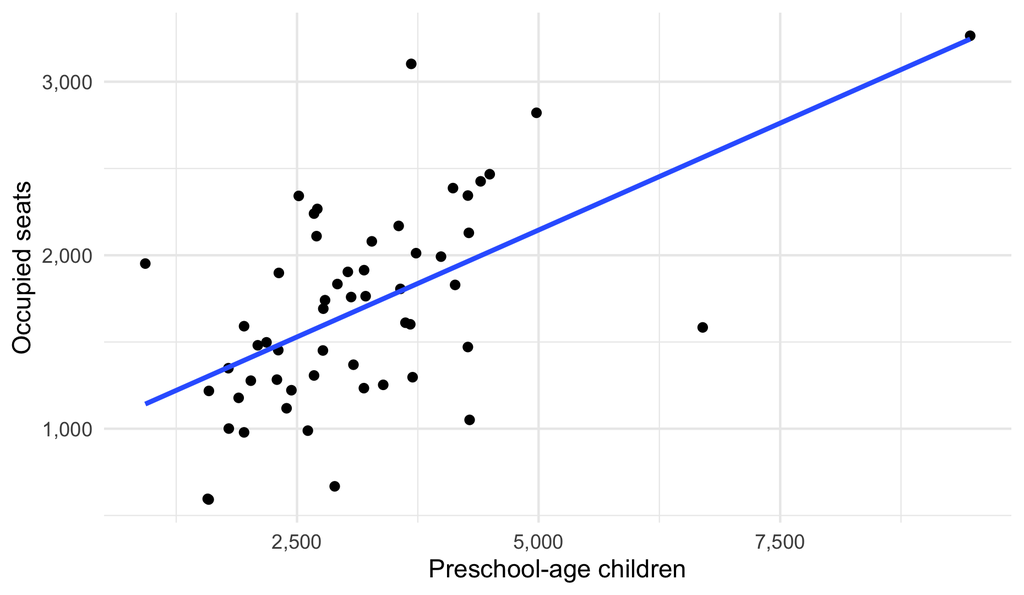

#### Occupied seats per child

Occupied seats per child is total seats minus vacant seats, divided by total preschool-age children.

#### Model

We take the log of occupied seats per preschool-age child and regress it on race/ethnicity shares and median household income at the PUMA level.

This model asks: after accounting for the size of the preschool-age population, are neighborhood racial/ethnic makeup or household income associated with having more or fewer occupied seats?

$$\begin{aligned}
\log\left(\frac{\text{licensed seats} - \text{vacant
seats}}{\text{preschool age children}}\right)
&= \beta_0 \\
&\quad + \beta_1(\text{Hispanic/Latino share}) \\
&\quad + \beta_2(\text{Black non-Hispanic share}) \\
&\quad + \beta_3(\text{Asian/API non-Hispanic share}) \\
&\quad + \beta_4(\text{median household income}) \\
&\quad + \epsilon
\end{aligned}$$

- **Asian/API non-Hispanic population share has the strongest relationship with occupied ECE seats.** A 10 percentage-point increase in Asian/API NH population share is associated with approximately 23% more occupied seats per preschool-age child.
- **Black non-Hispanic population share is positively associated with occupied seats per child, but the association is not statistically significant after adjusting for neighborhood income.**
- **Hispanic/Latino population share is not meaningfully associated with occupied seats per preschool-age child in this model.**
- **Median household income is not strongly associated with occupied seats per preschool-age child** after accounting for neighborhood racial/ethnic composition.

Model results: percent change in occupied seats per preschool-age child

| Predictor | Percent change | 95% CI Lower | 95% CI Upper | P-value |
| --- | --- | --- | --- | --- |
| Intercept | -59.2 | -78.6 | -22.3 | 0.01 |
| 10 percentage-point inc Hispanic/Latino | 1.8 | -4.8 | 8.8 | 0.60 |
| 10 percentage-point inc Black NH | 5.2 | -1.3 | 12.2 | 0.12 |
| 10 percentage-point inc Asian/API NH | 22.9 | 11.8 | 35.1 | 0.00 |
| $10,000 inc Median hh income | -2.1 | -6.1 | 2.0 | 0.30 |

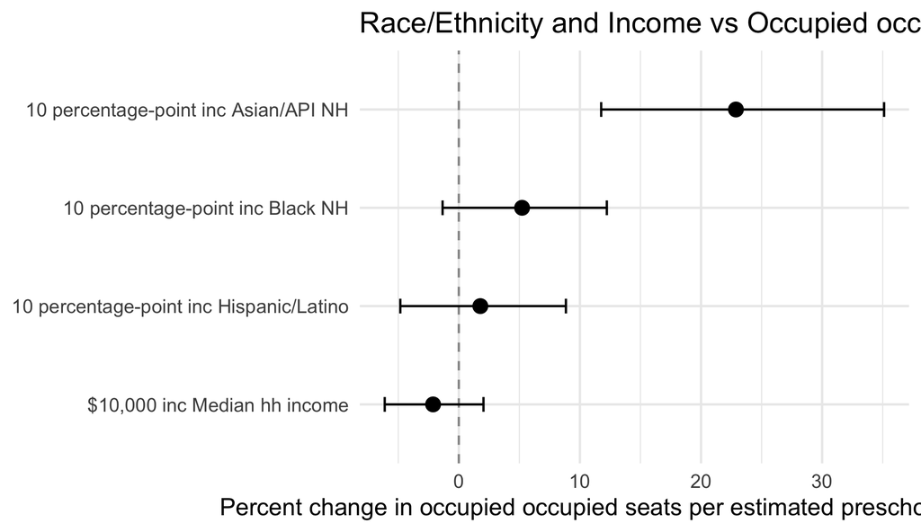

#### Map of occupied seats by PUMA

[interactive chart not shown]

#### Model Diagnostics

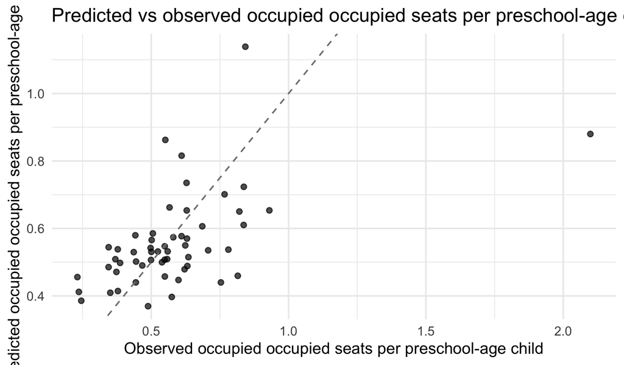

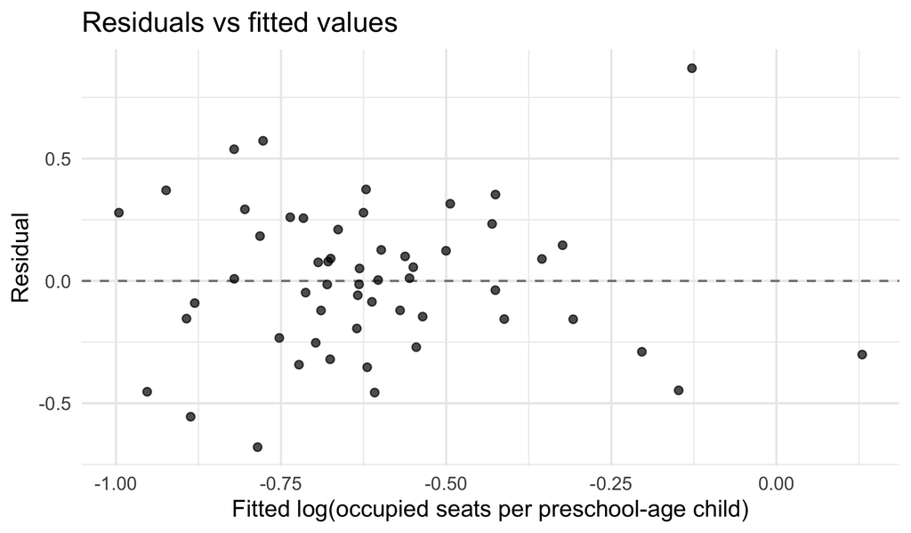

#### Robustness Checks

- **Black NH: Income explains very little of the relationship, but accounting for income increases uncertainty enough that the estimate is no longer significant.**
- **The Hispanic/Latino association is attenuated after adjustment for income**, implying that income accounts for most of the modest association observed in the model.
- **The Asian/API NH association remains large and highly statistically significant even after adjusting for income.**

Percent change in occupied seats per preschool-age child, with and without income adj

| Predictor | Race/ethnicity only model Without income | Race/ethnicity only model P-value without income | Race/ethnicity + income model With income | Race/ethnicity + income model P-value with income |
| --- | --- | --- | --- | --- |
| Hispanic/Latino | 4.2% (-0.7, 9.4) | 0.091 | 1.8% (-4.8, 8.8) | 0.600 |
| Black NH | 7.2% (1.7, 13.1) | 0.010 | 5.2% (-1.3, 12.2) | 0.119 |
| Asian/API NH | 25.0% (14.3, 36.6) | <0.001 | 22.9% (11.8, 35.1) | <0.001 |
| Median household income | NA | NA | -2.1% (-6.1, 2.0) | 0.305 |